# VersuchMusicClustering

## Vor dem Versuch zu klärende Fragen

### Transcodierung von MP3 nach WAV und Merkmalsextraktion

In diesem Versuch wird der MP3 Decoder [mpg123](http://www.mpg123.de/) eingesetzt. Installieren und testen sie diesen Decoder vor dem Versuch auf ihrem Rechner. Machen Sie sich zunächst mit dem in Kapitel Gegebene Module zur Transcodierung und Feature Extraction aufgeführten Code vertraut. Versuchen Sie Funktion und Ablauf dieses Programms zu verstehen und beantworten Sie folgende Fragen.

1.Was versteht man unter den statistischen Größen *Mittelwert, Standardabweichung, Skewness und Kurtosis*?

- unter dem Mittelwert versteht man den Wert, den man erhählt, wenn man alle Werte einer Stichprobe aufsummiert und diesen Wert dann durch die Anzahl der Werte teilt.
- die Standartabweichung gibt die Abweichung eines einzelnen Wertes vom Mittelwert an
- den Begriff der Skewness gibt es nur im Bezug auf asymmetrische Verteilung. Sie gibt an, wie stark die asymmetrie ist.
- Kurtosis beschreibt die "peaks" einer Verteilung and beschreibt wie stark diese um den Mittelwert sind

2.Was beschreibt die Fourier-Transformierte eines zeitlich ausgedehnten Signals?

- Sie beschreibt die Funktion, die das Spektrum beschreibt, welches durch die Fourier Transformation (zerlegte Signale) erzeugt wurde.

3.Mit welcher Samplingrate werden die WAV Dateien abgetastet?

- Die WAV Daten werden mit 10 kHz abgetastet, das bedeutet 10000 mal in der Sekunde

4.Insgesamt werden 42 Merkmale pro Musiksequenz extrahiert. Beschreiben Sie kurz diese Merkmale

- Es wird der Mittelwert, die Standardabweichung, die Kurtosis und die Skewness für meherer Blockgrößen berechnet 1, 10, 100 und 1000. Dadurch Außerdem noch die unterschieldichen Powerwerte.

### Genetischer Algorithmus für die Merkmalsselektion

       ```
         Bsp:
         a = [x1, x2, x3,   x4, x5, .... x42]
         b = [y1, y2, y3,   y4, y5, .... y42]
                          ^
                    Kreuzungspunkt

         a' = [x1, x2, x3, y4, y5, .... y42]
         b' = [y1, y2, y3, x4, x5, .....x42]
       ```

   - Mutation
     - Zwei Stellen im Zustandsvektor werden vertauscht

### Clustering und Playlistgenerierung

1. Wie kann mit einem hierarchischen Clustering der Musikfiles eine Menge von Playlists erzeugt werden, so dass innerhalb einer Playlist möglichst ähnliche Titel zu finden sind?

Man legt eine Mindestähnlichkeit M fest, die alle Songs in der Playlist zueinander haben sollen. Es werden alle Cluster ausgewählt die folgende Bedingungen erfüllen:

1. Alle Songs im Cluster C haben eine Mindestähnlichkeit M_c >= M
2. Cluster C ist in keinem anderen Cluster F enthalten, sodass M_f >= M und M_c > M_f

Durch 'depth first'-Iteration über jedes dieser Cluster entstehen die Playlisten.

Bei diesem Verfahren ist es wichtig, dass die Mindestähnlichkeit richtig gewählt wird. Dies hängt auch davon von ab wie ähnlich die Songs im Cluster sind. Bei einer zu strengen Mindestähnlichkeit kann es passieren, dass nur Playlisten mit jeweils einem Song entstehen. Bei zu geringer Mindestähnlichkeit klingt die Playliste eher zufällig als inhaltlich gruppiert.

# Durchführung

## Gegebene Module zur Transcodierung und Feature Extraction

Mit dem in diesem Abschnitt gegebenen Code werden die im Unterverzeichnis *BandCollection* befindlichen mp3-Files zunächst in wave decodiert. Danach werden aus den wave Dateien Audiomerkmale erhoben.

Von jedem Musikstück werden zwei disjunkte Teilsequenzen erhoben und von beiden Teilsequenzen jeweils ein Merkmalsvektor gebildet. Der Grund hierfür ist: Für die später folgende Bestimmung der wichtigsten Merkmale (Merkmalsselektion mit dem genetischen Algorithmus), wird angenommen dass Merkmale dann gut sind, wenn die aus ihnen gebildeten Merkmalsvektoren für Teilsequenzen des gleichen Musikstücks nahe beieinander liegen und die Merkmalsvektoren von Teilsequenzen unterschiedlicher Musikstücke weiter voneinander entfernt sind. In der Merkmalsselektion werden dann die Merkmale als relevant erachtet, für die diese Annahme zutrifft.

**Aufgaben:**

1. Stellen Sie im unten gegebenen Code die Verzeichnisse für Ihre Musikdateien (aktuell Unterverzeichnis *BandCollection*) und für den Ort Ihres *mpg123* Decoders richtig ein.
2. Die verwendete Musiksammlung sollte mindestens 5 verschiedene Interpreten möglichst unterschiedlicher Genres enthalten. Von jedem Interpret sollten mehrere Titel (evtl. ein ganzes Album) enthalten sein.
3. Führen Sie den in diesem Abschnitt gegebenen Programmcode zur Audiofeature-Extraction aus. Damit werden für alle Musiksequenzen jeweils 42 Merkmale extrahiert. Die extrahierten Merkmalsvektoren der jeweils ersten Sequenz werden in das File *FeatureFileTrainingAllList1.csv* geschrieben, die der zweiten Teilsequen in das File *FeatureFileTestAllList2.csv*.

```python
import subprocess
import wave
import struct
import numpy
import os
import pandas as pd

numpy.set_printoptions(precision=2,suppress=True)

#Names of features extracted in this module
FeatNames=["amp1mean","amp1std","amp1skew","amp1kurt","amp1dmean","amp1dstd","amp1dskew","amp1dkurt","amp10mean","amp10std",
           "amp10skew","amp10kurt","amp10dmean","amp10dstd","amp10dskew","amp10dkurt","amp100mean","amp100std","amp100skew",
           "amp100kurt","amp100dmean","amp100dstd","amp100dskew","amp100dkurt","amp1000mean","amp1000std","amp1000skew",
           "amp1000kurt","amp1000dmean","amp1000dstd","amp1000dskew","amp1000dkurt","power1","power2","power3","power4",
           "power5","power6","power7","power8","power9","power10"]
```

```python
def moments(x):
    mean = x.mean()
    std = x.var()**0.5
    skewness = ((x - mean)**3).mean() / std**3
    kurtosis = ((x - mean)**4).mean() / std**4
    return [mean, std, skewness, kurtosis]
```

```python
#Feature category 2: Frequency domain parameters
def fftfeatures(wavdata):
    f = numpy.fft.fft(wavdata)
    f = f[2:(f.size / 2 + 1)]
    f = abs(f)
    total_power = f.sum()
    f = numpy.array_split(f, 10)
    return [e.sum() / total_power for e in f]
```

```python
#Creating the entire feature vector per music-file
def features(x):
    x = numpy.array(x)
    f = []

    xs = x
    diff = xs[1:] - xs[:-1]
    f.extend(moments(xs))
    f.extend(moments(diff))

    xs = x.reshape(-1, 10).mean(1)
    diff = xs[1:] - xs[:-1]
    f.extend(moments(xs))
    f.extend(moments(diff))

    xs = x.reshape(-1, 100).mean(1)
    diff = xs[1:] - xs[:-1]
    f.extend(moments(xs))
    f.extend(moments(diff))

    xs = x.reshape(-1, 1000).mean(1)
    diff = xs[1:] - xs[:-1]
    f.extend(moments(xs))
    f.extend(moments(diff))

    f.extend(fftfeatures(x))
    return f
```

```python
def read_wav(wav_file):
    """Returns two chunks of sound data from wave file."""
    w = wave.open(wav_file)
    n = 60 * 10000
    if w.getnframes() < n * 3:
        raise ValueError('Wave file too short')
    #For each music file 2 sequences, each containing n frames are subtracted. The first sequence starts at postion n,
    #the second sequence starts at postion 2n. The reason for extracting 2 subsequences is, that later on we like to
    #find the best features and in this exercise we assume that good features have the property that they are similar for 2 subsequences
    #of the same song, but differ for subsequences of different songs.
    w.setpos(n)
    frames = w.readframes(n)
    wav_data1 = struct.unpack('%dh' % n, frames)
    frames = w.readframes(n)
    wav_data2 = struct.unpack('%dh' % n, frames)
    return wav_data1, wav_data2
```

```python
def compute_chunk_features(mp3_file):
    """Return feature vectors for two chunks of an MP3 file."""
    # Extract MP3 file to a mono, 10kHz WAV file
    #mpg123_command = 'C:\Program Files (x86)\mpg123-1.22.0-x86\mpg123-1.22.0-x86\\mpg123.exe -w "%s" -r 10000 -m "%s"'
    #mpg123_command = 'C:\\Program Files (x86)\\mpg123-1.21.0-x86-64\\mpg123.exe -w "%s" -r 10000 -m "%s"'
    mpg123_command = '/usr/local/bin/mpg123 -w "%s" -r 10000 -m "%s"'
    out_file = 'temp.wav'
    cmd = mpg123_command % (out_file, mp3_file)
    temp = subprocess.call(cmd, shell=True)
    # Read in chunks of data from WAV file
    wav_data1, wav_data2 = read_wav(out_file)
    # We'll cover how the features are computed in the next section!
    return numpy.array(features(wav_data1)), numpy.array(features(wav_data2))
```

```python
fileList=[]
featureList1=[]
featureList2=[]
#Specify the name of the directory, which contains your MP3 files here.
# This directory should contain for each band/author one subdirectory, which contains all songs of this author
for path, dirs, files in os.walk('./BandCollection'):
    #print '-'*10,dirs,files
    for f in files:
        if not f.endswith('.mp3'):
            # Skip any non-MP3 files
            continue
        mp3_file = os.path.join(path, f)
        #print mp3_file
        # Extract the track name (i.e. the file name) plus the names
        # of the two preceding directories. This will be useful
        # later for plotting.
        tail, track = os.path.split(mp3_file)
        tail, dir1 = os.path.split(tail)
        tail, dir2 = os.path.split(tail)
        # Compute features. feature_vec1 and feature_vec2 are lists of floating
        # point numbers representing the statistical features we have extracted
        # from the raw sound data.
        try:
            feature_vec1, feature_vec2 = compute_chunk_features(mp3_file)
        except:
            print "Error: Chunk Features failed"
            continue
        #title=str(track)
        title=str(dir1)+'\\'+str(track)
        print '-'*20+ title +'-'*20
        #print "       feature vector 1:",feature_vec1
        #print "       feature vector 2:",feature_vec2
        fileList.append(title)
        featureList1.append(feature_vec1)
        featureList2.append(feature_vec2)

# Write feature vecotrs of all music files to pandas data-frame
MusicFeaturesTrain=pd.DataFrame(index=fileList,data=numpy.array(featureList1),columns=FeatNames)
MusicFeaturesTrain.to_csv("FeatureFileTrainingAllList1.csv")

MusicFeaturesTest=pd.DataFrame(index=fileList,data=numpy.array(featureList2),columns=FeatNames)
MusicFeaturesTest.to_csv("FeatureFileTestAllList2.csv")
```

```
--------------------Adele\01 Hometown Glory.mp3--------------------
--------------------Adele\02 I'll Be Waiting.mp3--------------------
--------------------Adele\03 Don't You Remember.mp3--------------------
--------------------Adele\04 Turning Tables.mp3--------------------
--------------------Adele\05 Set Fire To The Rain.mp3--------------------
--------------------Adele\06 If It Hadn't Been For Love.mp3--------------------
Error: Chunk Features failed
--------------------Adele\08 Take It All.mp3--------------------
--------------------Adele\09 Rumour Has It.mp3--------------------
Error: Chunk Features failed
--------------------Adele\11 One And Only.mp3--------------------
--------------------Adele\12 Lovesong.mp3--------------------
--------------------Adele\13 Chasing Pavements.mp3--------------------
--------------------Adele\14 I Can't Make You Love Me.mp3--------------------
--------------------Adele\15 Make You Feel My Love.mp3--------------------
--------------------Adele\16 Someone Like You.mp3--------------------
--------------------Adele\17 Rolling In The Deep.mp3--------------------
--------------------BeastieBoys\01 So What'cha Want.mp3--------------------
Error: Chunk Features failed
--------------------BeastieBoys\03 Ch-Check It Out.mp3--------------------
--------------------BeastieBoys\04 No Sleep Till Brooklyn.mp3--------------------
--------------------BeastieBoys\05 Hey Ladies.mp3--------------------
--------------------BeastieBoys\06 Pass the Mic.mp3--------------------
--------------------BeastieBoys\07 An Open Letter to NYC.mp3--------------------
--------------------BeastieBoys\08 Root Down.mp3--------------------
--------------------BeastieBoys\09 Shake Your Rump.mp3--------------------
--------------------BeastieBoys\10 Intergalactic.mp3--------------------
--------------------BeastieBoys\11 Sure Shot.mp3--------------------
--------------------BeastieBoys\12 Body Movin' (Fatboy Slim Remix).mp3--------------------
Error: Chunk Features failed
Error: Chunk Features failed
--------------------BeastieBoys\15 Fight for Your Right.mp3--------------------
--------------------Garrett\01 Smooth Criminal 1.mp3--------------------
--------------------Garrett\02 Who Wants to Live Forever_ 1.mp3--------------------
--------------------Garrett\03 Clair de Lune 1.mp3--------------------
--------------------Garrett\04 He's a Pirate (Pirates of the Car 1.mp3--------------------
--------------------Garrett\05 Summertime 1.mp3--------------------
Error: Chunk Features failed
Error: Chunk Features failed
Error: Chunk Features failed
```

[output cut: 15 more lines]

```
--------------------LanaDelRey\08 Radio.mp3--------------------
--------------------LanaDelRey\09 Carmen.mp3--------------------
--------------------LanaDelRey\10 Million Dollar Man.mp3--------------------
--------------------LanaDelRey\11 Summertime Sadness.mp3--------------------
--------------------LanaDelRey\12 This Is What Makes Us Girls.mp3--------------------
--------------------RageAgainstTheMachine\01 Bombtrack.mp3--------------------
--------------------RageAgainstTheMachine\02 Killing In the Name.mp3--------------------
--------------------RageAgainstTheMachine\03 Take the Power Back.mp3--------------------
--------------------RageAgainstTheMachine\04 Settle for Nothing.mp3--------------------
--------------------RageAgainstTheMachine\05 Bullet In the Head.mp3--------------------
--------------------RageAgainstTheMachine\06 Know Your Enemy.mp3--------------------
--------------------RageAgainstTheMachine\07 Wake Up.mp3--------------------
--------------------RageAgainstTheMachine\08 Fistful of Steel.mp3--------------------
--------------------RageAgainstTheMachine\09 Township Rebellion.mp3--------------------
--------------------RageAgainstTheMachine\10 Freedom.mp3--------------------
```

## Matching der Teilsequenzen

In diesem Abschnitt soll ein Verfahren implementiert werden, mit dem die Übereinstimmung der ersten Teilsequenz eines Musikstücks mit den zweiten Teilsequenzen aller anderen Musikstücke berechnet werden kann.

**Aufagben:** 1.Lesen Sie die im vorigen Teilversuch angelegten zwei csv-Dateien in jeweils einen eigenen Pandas Dataframe ein.

```python
import pandas as pd
from sklearn.preprocessing import StandardScaler
scale = StandardScaler()

MusicFeaturesTrain = pd.read_csv('./FeatureFileTrainingAllList1.csv')
MusicFeaturesTest = pd.read_csv('./FeatureFileTestAllList2.csv')

collist = MusicFeaturesTrain.columns.tolist()[1:]
MusicFeaturesTrain[collist] = scale.fit_transform(MusicFeaturesTrain[collist].as_matrix())

MusicFeaturesTest[collist] = scale.fit_transform(MusicFeaturesTest[collist].as_matrix())
```

2.Bestimmen Sie zu jeder Teilsequenz aus der Datei *FeatureFileTrainingAllList1.csv* die euklidische Distanz zu allen Teilsequenzen aus der Datei *FeatureFileTestAllList2.csv* und schreiben Sie diese Distanzen in eine aufsteigend geordnete Liste. Schreiben Sie auch die zugehörigen Argumente (Teilsequenzen) in eine geordnete Liste, sodass für jede Teilsequenz aus *FeatureFileTrainingAllList1.csv* die am nächsten liegende Teilsequenz aus *FeatureFileTestAllList2.csv* an erster Stelle steht, die zweitnächste Teilsequenz an zweiter usw.

```python
from scipy.spatial.distance import euclidean

def get_euclid_dist(seq1, seq2):
    return euclidean(seq1, seq2)
```

```python
distance_dict_euc = {}

for seq1 in MusicFeaturesTrain.iterrows():
    seq1_vector_tuple = (seq1[1].values[:1][0], seq1[1].values[1:])
    dist_list = []

    for seq2 in MusicFeaturesTest.iterrows():
        seq2_vector_tuple = (seq2[1].values[:1][0], seq2[1].values[1:])
        distance = get_euclid_dist(seq1_vector_tuple[1], seq2_vector_tuple[1])

        dist_list.append((seq2_vector_tuple[0], distance))

    dist_list.sort(key=lambda x: x[1])
    distance_dict_euc[seq1_vector_tuple[0]] = dist_list

distance_dict_euc.items()[:1]
```

```
[('LanaDelRey\\02 Off to the Races.mp3',
  [('BeastieBoys\\06 Pass the Mic.mp3', 5.0798898249250684),
   ('LanaDelRey\\12 This Is What Makes Us Girls.mp3', 6.68111149637968),
   ('LanaDelRey\\07 Dark Paradise.mp3', 6.8159469514778532),
   ('RageAgainstTheMachine\\10 Freedom.mp3', 6.8473651472989046),
   ('LanaDelRey\\08 Radio.mp3', 6.9155745458343487),
   ("BeastieBoys\\12 Body Movin' (Fatboy Slim Remix).mp3", 7.0025235850786345),
   ('LanaDelRey\\09 Carmen.mp3', 7.0171643942515347),
   ("Garrett\\04 He's a Pirate (Pirates of the Car 1.mp3", 7.3800621194004181),
   ('BeastieBoys\\07 An Open Letter to NYC.mp3', 7.432101149474895),
   ('LanaDelRey\\02 Off to the Races.mp3', 7.5450429614224941),
   ('Garrett\\11 Thunderstruck.mp3', 7.594664702689828),
   ('Adele\\12 Lovesong.mp3', 7.6922242583208726),
   ('Garrett\\05 Summertime 1.mp3', 7.7321860167509096),
   ('Adele\\17 Rolling In The Deep.mp3', 7.8413334683198217),
   ('Adele\\11 One And Only.mp3', 8.0035252032406596),
   ('RageAgainstTheMachine\\09 Township Rebellion.mp3', 8.0443748231413927),
   ('RageAgainstTheMachine\\07 Wake Up.mp3', 8.1187686399582475),
   ('BeastieBoys\\03 Ch-Check It Out.mp3', 8.1730442491484823),
   ('LanaDelRey\\01 Born to Die.mp3', 8.3198477829635955),
   ('RageAgainstTheMachine\\06 Know Your Enemy.mp3', 8.3282355862383426),
   ('LanaDelRey\\11 Summertime Sadness.mp3', 8.3402164815606508),
   ('LanaDelRey\\03 Blue Jeans (Remastered).mp3', 8.3508666543867882),
   ('Garrett\\02 Who Wants to Live Forever_ 1.mp3', 8.4521136098674958),
   ('RageAgainstTheMachine\\05 Bullet In the Head.mp3', 8.4832582515009367),
   ('LanaDelRey\\04 Video Games (Remastered).mp3', 8.5196914708257996),
   ('RageAgainstTheMachine\\01 Bombtrack.mp3', 8.6251657798252097),
   ('BeastieBoys\\08 Root Down.mp3', 8.7460594262856635),
   ('LanaDelRey\\06 National Anthem.mp3', 8.7687026464386051),
   ("Adele\\02 I'll Be Waiting.mp3", 8.7932356369736109),
   ('Garrett\\10 Air.mp3', 8.9668235961404132),
   ("Adele\\03 Don't You Remember.mp3", 8.9676026500435402),
   ('RageAgainstTheMachine\\02 Killing In the Name.mp3', 9.1002139020836292),
   ('LanaDelRey\\05 Diet Mountain Dew.mp3', 9.1888577133131744),
   ('Adele\\13 Chasing Pavements.mp3', 9.339951330068704),
   ('Adele\\09 Rumour Has It.mp3', 9.3781920533965852),
   ('RageAgainstTheMachine\\04 Settle for Nothing.mp3', 9.5648931831920017),
   ('Garrett\\14 Rock Prelude.mp3', 9.5958378132138762),
   ('Garrett\\12 New Day.mp3', 9.6692676543902341),
   ('Garrett\\09 O Mio Babbino Caro 1.mp3', 9.7665248973421654),
   ("Adele\\06 If It Hadn't Been For Love.mp3", 9.8263780636531326),
   ('RageAgainstTheMachine\\03 Take the Power Back.mp3', 9.8732310714821097),
   ('Garrett\\01 Smooth Criminal 1.mp3', 9.9086356170738448),
   ('Adele\\01 Hometown Glory.mp3', 10.221189770807779),
   ('Garrett\\03 Clair de Lune 1.mp3', 10.227821194437883),
   ('LanaDelRey\\10 Million Dollar Man.mp3', 10.304203339865165),
   ('BeastieBoys\\10 Intergalactic.mp3', 10.335952404865481),
   ('Adele\\05 Set Fire To The Rain.mp3', 10.502521142491124),
   ('Adele\\16 Someone Like You.mp3', 10.568324129792282),
   ('Adele\\04 Turning Tables.mp3', 10.568377695115588),
   ('Adele\\08 Take It All.mp3', 10.588084186924531),
   ('BeastieBoys\\15 Fight for Your Right.mp3', 10.607195535160125),
   ("Adele\\14 I Can't Make You Love Me.mp3", 10.741896767972477),
   ('BeastieBoys\\11 Sure Shot.mp3', 10.97393452543689),
   ('Adele\\15 Make You Feel My Love.mp3', 10.996242204237076),
   ('Garrett\\16 Little Wing.mp3', 11.478156691685276),
   ('RageAgainstTheMachine\\08 Fistful of Steel.mp3', 11.746989452089087),
   ('BeastieBoys\\04 No Sleep Till Brooklyn.mp3', 12.884293556605938),
   ('BeastieBoys\\09 Shake Your Rump.mp3', 13.551114724860946),
   ("BeastieBoys\\01 So What'cha Want.mp3", 13.700866448346172),
   ('BeastieBoys\\05 Hey Ladies.mp3', 14.915592115689089)])]
```

3.Bestimmen Sie über alle Teilsequenzen aus *FeatureFileTrainingAllList1.csv* den **mittleren Rang** an dem die zugehörige zweite Teilsequenz erscheint. Liegt z.B. für die erste Teilsequenz des Musikstücks A die zweite Teilsequenz nur an fünfter Stelle der geordneten nächsten Nachbarliste. Dann würde diese Teilsequenz mit dem Rang 5 in den Mittelwert einfließen.

```python
distance_vals = []

for seq1, seqs  in distance_dict_euc.items():
    for index, seq in enumerate(seqs):
        if seq[0] == seq1:
            distance_vals.append(index + 1)
            break

avg_euclid = sum(distance_vals) / float(len(distance_vals))

print distance_vals
print 'Durchschnittliche Distanz: ' + str(avg_euclid)
```

[output not shown]

4.Bestimmen Sie jetzt den mittleren Rang, für den Fall, dass *correlation* anstelle *euclidean* als Ähnlichkeitsmaß verwendet wird. Welches Ähnlichkeitsmaß ist für diese Anwendung zu bevorzugen?

```python
from scipy.spatial.distance import correlation

def get_corr_dist(seq1, seq2):
    return correlation(seq1, seq2)
```

```python
distance_dict_corr = {}

for seq1 in MusicFeaturesTrain.iterrows():
    seq1_vector_tuple = (seq1[1].values[:1][0], seq1[1].values[1:])
    dist_list = []

    for seq2 in MusicFeaturesTest.iterrows():
        seq2_vector_tuple = (seq2[1].values[:1][0], seq2[1].values[1:])
        distance = get_corr_dist(seq1_vector_tuple[1], seq2_vector_tuple[1])

        dist_list.append((seq2_vector_tuple[0], distance))

    dist_list.sort(key=lambda x: x[1])
    distance_dict_corr[seq1_vector_tuple[0]] = dist_list

distance_dict_corr.items()[:1]
```

```
[('LanaDelRey\\02 Off to the Races.mp3',
  [('BeastieBoys\\06 Pass the Mic.mp3', 0.24326409569075658),
   ('LanaDelRey\\09 Carmen.mp3', 0.47598591340250418),
   ('LanaDelRey\\08 Radio.mp3', 0.58261805107703835),
   ('LanaDelRey\\02 Off to the Races.mp3', 0.58799975479689826),
   ('RageAgainstTheMachine\\10 Freedom.mp3', 0.59835419629745568),
   ('LanaDelRey\\07 Dark Paradise.mp3', 0.60236972529448907),
   ('LanaDelRey\\12 This Is What Makes Us Girls.mp3', 0.60719320745371697),
   ('BeastieBoys\\03 Ch-Check It Out.mp3', 0.62523854075726781),
   ('BeastieBoys\\07 An Open Letter to NYC.mp3', 0.63492007624795233),
   ('BeastieBoys\\10 Intergalactic.mp3', 0.74919225875841544),
   ('LanaDelRey\\06 National Anthem.mp3', 0.7654348415054224),
   ("BeastieBoys\\12 Body Movin' (Fatboy Slim Remix).mp3",
    0.81249870243007005),
   ('BeastieBoys\\08 Root Down.mp3', 0.83194030373975036),
   ("Garrett\\04 He's a Pirate (Pirates of the Car 1.mp3",
    0.87311745258147411),
   ('BeastieBoys\\11 Sure Shot.mp3', 0.88817875864357665),
   ('LanaDelRey\\04 Video Games (Remastered).mp3', 0.89598272691835446),
   ('Garrett\\10 Air.mp3', 0.90330658051967716),
   ('LanaDelRey\\01 Born to Die.mp3', 0.91479887337247989),
   ('Adele\\11 One And Only.mp3', 0.93686278623767016),
   ('RageAgainstTheMachine\\09 Township Rebellion.mp3', 0.94416346704314025),
   ('Adele\\12 Lovesong.mp3', 0.95940589231600404),
   ('Garrett\\11 Thunderstruck.mp3', 0.96669635611097227),
   ('RageAgainstTheMachine\\05 Bullet In the Head.mp3', 0.96876294164356214),
   ('Garrett\\01 Smooth Criminal 1.mp3', 0.96888994377283832),
   ('LanaDelRey\\03 Blue Jeans (Remastered).mp3', 0.97468874004909223),
   ('LanaDelRey\\11 Summertime Sadness.mp3', 0.99865882129885408),
   ('BeastieBoys\\15 Fight for Your Right.mp3', 1.0160942513656579),
   ('Garrett\\14 Rock Prelude.mp3', 1.0173211831810924),
   ('LanaDelRey\\05 Diet Mountain Dew.mp3', 1.0335530619259057),
   ('RageAgainstTheMachine\\08 Fistful of Steel.mp3', 1.0483652749652286),
   ('RageAgainstTheMachine\\06 Know Your Enemy.mp3', 1.0580275468869511),
   ('BeastieBoys\\09 Shake Your Rump.mp3', 1.0637008009150519),
   ('Adele\\17 Rolling In The Deep.mp3', 1.0637142209124444),
   ('BeastieBoys\\04 No Sleep Till Brooklyn.mp3', 1.0648656530302683),
   ('Adele\\16 Someone Like You.mp3', 1.1048137935033817),
   ('Adele\\15 Make You Feel My Love.mp3', 1.1269023791249941),
   ('Garrett\\05 Summertime 1.mp3', 1.1346098760992067),
```

[output cut: 8 more lines]

```
   ('Garrett\\03 Clair de Lune 1.mp3', 1.1920432805844443),
   ('Garrett\\16 Little Wing.mp3', 1.202470356814872),
   ('Adele\\01 Hometown Glory.mp3', 1.2128123385855454),
   ('Adele\\08 Take It All.mp3', 1.2208714587333074),
   ('Garrett\\09 O Mio Babbino Caro 1.mp3', 1.2236333291076353),
   ("Adele\\03 Don't You Remember.mp3", 1.232532575582687),
   ('RageAgainstTheMachine\\04 Settle for Nothing.mp3', 1.2380281553203349),
   ('RageAgainstTheMachine\\01 Bombtrack.mp3', 1.2422995727531991),
   ("Adele\\14 I Can't Make You Love Me.mp3", 1.2554272708646408),
   ('LanaDelRey\\10 Million Dollar Man.mp3', 1.2782730516294856),
   ('Adele\\04 Turning Tables.mp3', 1.304459207364262),
   ("Adele\\02 I'll Be Waiting.mp3", 1.3112562118759628),
   ('Garrett\\12 New Day.mp3', 1.3185248884881822),
   ('Adele\\13 Chasing Pavements.mp3', 1.3293204883545804),
   ('Adele\\05 Set Fire To The Rain.mp3', 1.3345221713155966)])]
```

```python
distance_vals = []

for seq1, seqs  in distance_dict_corr.items():
    for index, seq in enumerate(seqs):
        if seq[0] == seq1:
            distance_vals.append(index + 1)
            break

avg_correlation = sum(distance_vals) / float(len(distance_vals))

print distance_vals
print 'Durchschnittliche Distanz: ' + str(avg_correlation)
```

[output not shown]

5.Diskutieren Sie das Ergebnis

### Auswertung:

Der Euclid bietet in diesem Fall die bessere Bewertung der beiden Sequenz-Vektoren, da es sein kann, dass die correlation der beiden sequenzen vom selben Lied trotzdem unterschiedlich sind weil einige Lieder sich in der zweiten Sequenz nicht mehr genau anhöhren wie in der Zweiten.

Die euclidische Distanz zwischen den beiden Sequenzen gibt bei normalisierten Daten einen kleinen aber entscheidenden Unterschied bei der Bewertung.

Falls z.B. die Riehenfolge der Töne bei der zweiten sequenz vertauscht sind, wird die Correlation sehr einen ziemlich großen Abweichungswert haben, die euclidische Distanz dagegen wird weniger stark davon beeinflusst und kann so ähnliche Lieder, bzw. in diesem Fall Sequenzen, besser finden.

## Merkmalsauswahl mit dem genetischen Algorithmus

In diesem Abschnitt soll unter Anwendung eines selbst zu implementierenden genetischen Algorithmus eine Untermenge wichtiger Merkmale aus den insgesamt 42 angelegten Merkmalen berechnet werden. Als Vorlage kann hierfür die Implementierung für die [Lösung des TSP Problems](https://www.hdm-stuttgart.de/~maucher/Python/FunktionenAlgorithmen/html/genAlgTSP.html) herangezogen werden. Anzupassen sind dann jedoch mindestens die Fitness-Funktion, die Kreuzungs- und die Mutationsfunktion. Die Fitness soll so wie im vorigen Teilabschnitt mit dem mittleren Rang berechnet werden. Die Populationsgröße, die Anzahl der auszuwählenden Merkmale und die Anzahl der Iterationen sollen als Parameter einstellbar sein.

Der Fitnesswert des besten Individuums in der Population soll in jeder Iteration gespeichert werden. Der Verlauf dieses besten Fitness-Wertes über den Fortlauf der **Iterationen soll graphisch ausgegeben** werden.

Ein Pandas Frame, der nur die berechneten **wichtigsten Merkmale aus *FeatureFileTrainingAllList1.csv* enthält soll angelegt und in die csv Datei *subFeaturesTrain1.csv* geschrieben** werden.

**Aufgaben:**

1. Implementieren Sie die die Merkmalsauswahl mit dem genetischen Algorithmus entsprechend der o.g. Beschreibung
2. Beschreiben Sie kurz das Konzept ihrer Kreuzungs- und Mutationsfunktion.

Unser Code ist eine Adaption der Referenzlösung für das TSP Problem. Die Mutations- und Kreuzungsfunktionen sind sogar noch einfacher. Der Merkmalsvektor hat die Länge n=42. Jede Stelle representiert ein Musikmerkmal. Der Wert kann entweder 1 oder 0 sein. Ist der Wert 1 wird das Merkmal beachtet bei der Distanzberechnung, ansonsten wird das Merkmal ignoriert

- **Kreuzungsfunktion:**

  Es wird an einer zufälligen Stelle die Merkmalsvektoren gesplitet und wieder über kreuz zusammengesetzt um 2 Kinder zu erzeugen
- **Mutationsfunktion:**

  2 Zufällige Stellen werden im Merkmalsvektor vertauscht

3.Bestimmen Sie eine möglichst kleine Merkmalsuntermenge mit einem möglichst guten mittleren Rang? Geben Sie sowohl die gefundenen wichtigsten Merkmale als auch den zugehörigen mittleren Rang an.  
4.Um wieviel verschlechtert sich der Mittlere Rang, wenn nur die 10 wichtigsten Merkmale benutzt werden?

```python
def calculate_cost(imp_feature_vec):
    distance_dict_euclid = {}

    for seq1 in MusicFeaturesTrain.iterrows():
        seq1_vector_tuple = (seq1[1].values[:1][0], get_modified_features(seq1[1].values[1:], imp_feature_vec))
        dist_list = []

        for seq2 in MusicFeaturesTest.iterrows():
            seq2_vector_tuple = (seq2[1].values[:1][0], get_modified_features(seq2[1].values[1:], imp_feature_vec))
            distance = get_euclid_dist(seq1_vector_tuple[1], seq2_vector_tuple[1])

            dist_list.append((seq2_vector_tuple[0], distance))

        dist_list.sort(key=lambda x: x[1])
        distance_dict_euclid[seq1_vector_tuple[0]] = dist_list

    distance_vals = []

    for seq1, seqs  in distance_dict_euclid.items():
        for index, seq in enumerate(seqs):
            if seq[0] == seq1:
                distance_vals.append(index + 1)
                break

    avg_euclid = sum(distance_vals) / float(len(distance_vals))

    return avg_euclid
```

```python
def get_modified_features(feature_vec, imp_feature_vec):
    new_feature_vec = []
    for index, feature in enumerate(feature_vec):
        new_feature_vec.append(feature * imp_feature_vec[index])
    return new_feature_vec
```

```python
middle_range_test = calculate_cost([0, 1, 0, 1, 1, 0, 0, 0, 1, 0, 1, 1, 0, 1, 1, 0, 1, 1, 0, 1, 0, 0, 0, 0, 0, 0, 0, 0, 1, 0, 0, 1, 0, 0, 1, 0, 1, 1, 1, 1, 1, 1])
print 'Middle range for this vector is: ' + str(middle_range_test)
```

```
Middle range for this vector is: 3.96666666667
```

#### Genetischer Algorithmus für die Music Feature Selection

```python
# -*- coding:utf-8 -*-
import numpy as np
from scipy.spatial.distance import pdist,squareform

np.random.seed()

###########################################################################
#              Genetischer Algorithmus zur Lösung des TSP                 #
###########################################################################

ITERATIONS=50;
POPULATION_SIZE=50;
CROSSPROP=0.99;
MUTPROP=0.5;
NUMBER_OF_FEATURES=42

iteration = 0;

#In diesem Array wird für jede Iteration die beste Distanz gespeichert
bestDist=np.zeros(ITERATIONS)


#Erzeugen einer zufälligen Startpopulation
population= np.array([ np.random.randint(2, size=NUMBER_OF_FEATURES) for i in range(POPULATION_SIZE) ])

cost=np.zeros(POPULATION_SIZE)

for iteration in range(ITERATIONS):

    for (i, pop) in enumerate(population):
        cost[i]=calculate_cost(pop)

    sortedIndex=cost.argsort(axis=0)#Indizees der nach ansteigenden Kosten sortierten Chromosomen
    sortedCost=cost[sortedIndex] #die ansteigend sortierten Kosten
    bestDist[iteration]=sortedCost[0]

    print 'Iteration: ', str(iteration), 'best distance: ', bestDist[iteration]

    sortedPopulation=population[sortedIndex] #Sortierung der Population nach ansteigenden Kosten
    InvertedCost=1/(sortedCost + 0.001) #Berechung des Nutzen (Fitness) aus den Kosten
    #InvertedCost enthält die berechneten Fitness-Werte


    # 2.Selektion: Zufällige Auswahl von Chromosomen aus der Population####################
    # Mit dem folgenden Prozess wird gewährleistet, dass die Wahrscheinlichkeit für die
    # Selektion eines Chromosoms umso größer ist, je größer sein Nutzenwert ist.
    InvertedCostSum = InvertedCost.sum()
    rn1 = InvertedCostSum*np.random.rand()
    found1 = False
    index=1
    while not found1:
            if rn1<InvertedCost[:index].sum(axis=0):
                    found1=index
            else:
                    index+=1
    found1=found1-1
    equal=True

    while equal:
            rn2=InvertedCostSum*np.random.rand()
            found2 = False
            index=1
            while not found2:
                    if rn2<InvertedCost[:index].sum(axis=0):
                            found2=index
                    else:
                            index+=1
            found2=found2-1
            if found2 != found1:
                    equal=False
    parent1=sortedPopulation[found1]
    parent2=sortedPopulation[found2]

    crossrn=np.random.rand()
    if crossrn<CROSSPROP:
        cp=np.ceil(np.random.rand()*NUMBER_OF_FEATURES)
        head1=parent1[:cp]
        tail1=parent1[cp:]
        head2=parent2[:cp]
        tail2=parent2[cp:]

        child1=np.append(head1,tail2)
        child2=np.append(head2,tail1)


    #4. Mutation#########################################################################################
        mutrn=np.random.rand()
        if mutrn<MUTPROP:
            mutInd=np.ceil(np.random.rand(2)*(NUMBER_OF_FEATURES-1))
            first=child1[mutInd[0]]
            second=child1[mutInd[1]]
            child1[mutInd[0]]=second
            child1[mutInd[1]]=first

        mutrn=np.random.rand()
        if mutrn<MUTPROP:
            mutInd=np.ceil(np.random.rand(2)*(NUMBER_OF_FEATURES-1))
            first=child2[mutInd[0]]
            second=child2[mutInd[1]]
            child2[mutInd[0]]=second
            child2[mutInd[1]]=first

        #child1 und child2 sind die Resultate der Mutation################################################


    #5. Ersetze die bisher schlechtesten Chromosomen durch die neu gebildeten Chromosomen, falls die neuen
    #besser sind
    costChild1=calculate_cost(child1)
    costChild2=calculate_cost(child2)

    replace1=False
    replace2=False
    index=POPULATION_SIZE-1

    while index > 0:
            if sortedCost[index]>costChild1 and not replace1:
                    if not np.ndarray.any(np.ndarray.all(child1==sortedPopulation,axis=1)):
                            sortedPopulation[index]=child1
                    replace1=True
            elif sortedCost[index]>costChild2 and not replace2:
                    if not np.ndarray.any(np.ndarray.all(child2==sortedPopulation,axis=1)):
                            sortedPopulation[index]=child2
                    replace2=True
            if replace1 and replace2:
                    break
            index=index-1
    population=sortedPopulation

print bestDist
print population
```

```
Iteration:  0 best distance:  1.83333333333
```

```
Iteration:  1 best distance:  1.83333333333
Iteration:  2 best distance:  1.83333333333
```

```
Iteration:  3 best distance:  1.83333333333
Iteration:  4 best distance:  1.83333333333
Iteration:  5 best distance:  1.83333333333
Iteration:  6 best distance:  1.83333333333
Iteration:  7 best distance:  1.83333333333
Iteration:  8 best distance:  1.83333333333
Iteration:  9 best distance:  1.83333333333
Iteration:  10 best distance:  1.83333333333
Iteration:  11 best distance:  1.83333333333
Iteration:  12 best distance:  1.83333333333
Iteration:  13 best distance:  1.83333333333
Iteration:  14 best distance:  1.83333333333
Iteration:  15 best distance:  1.83333333333
Iteration:  16 best distance:  1.83333333333
Iteration:  17 best distance:  1.83333333333
Iteration:  18 best distance:  1.83333333333
Iteration:  19 best distance:  1.83333333333
Iteration:  20 best distance:  1.83333333333
Iteration:  21 best distance:  1.83333333333
Iteration:  22 best distance:  1.83333333333
Iteration:  23 best distance:  1.83333333333
Iteration:  24 best distance:  1.83333333333
Iteration:  25 best distance:  1.83333333333
Iteration:  26 best distance:  1.83333333333
Iteration:  27 best distance:  1.83333333333
Iteration:  28 best distance:  1.83333333333
Iteration:  29 best distance:  1.83333333333
Iteration:  30 best distance:  1.83333333333
Iteration:  31 best distance:  1.83333333333
Iteration:  32 best distance:  1.83333333333
Iteration:  33 best distance:  1.83333333333
Iteration:  34 best distance:  1.83333333333
Iteration:  35 best distance:  1.83333333333
Iteration:  36 best distance:  1.83333333333
Iteration:  37 best distance:  1.83333333333
Iteration:  38 best distance:  1.83333333333
Iteration:  39 best distance:  1.83333333333
Iteration:  40 best distance:  1.83333333333
Iteration:  41 best distance:  1.83333333333
Iteration:  42 best distance:  1.83333333333
```

[output cut: 8 more lines]

```
  1.83333333  1.83333333  1.83333333  1.83333333  1.83333333  1.83333333
  1.83333333  1.83333333  1.83333333  1.83333333  1.83333333  1.83333333
  1.83333333  1.83333333  1.83333333  1.83333333  1.83333333  1.83333333
  1.83333333  1.83333333  1.83333333  1.83333333  1.83333333  1.83333333
  1.83333333  1.83333333  1.83333333  1.83333333  1.83333333  1.83333333
  1.83333333  1.83333333  1.83333333  1.83333333  1.83333333  1.83333333
  1.83333333  1.83333333  1.83333333  1.83333333  1.83333333  1.83333333
  1.83333333  1.83333333]
[[0 0 1 ..., 1 1 0]
 [0 0 1 ..., 1 0 1]
 [0 1 0 ..., 1 1 1]
 ...,
 [0 0 0 ..., 0 1 0]
 [1 1 0 ..., 0 1 1]
 [0 1 0 ..., 1 1 1]]
```

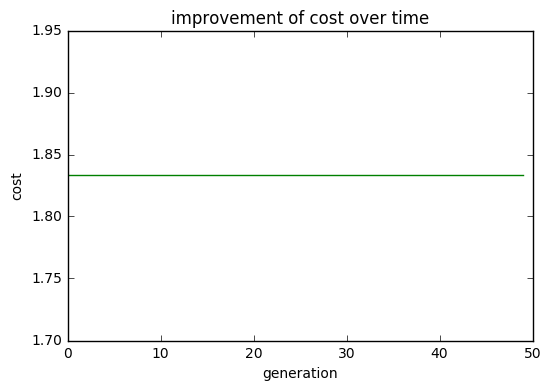

```python
%matplotlib inline
from matplotlib import pyplot as plt

plt.plot(range(len(bestDist)), bestDist, color="green")
plt.xlabel("generation")
plt.ylabel("cost")
plt.title("improvement of cost over time")
```

### Beobachtungen

Mit den Einstellungen:  
ITERATIONS=50;  
POPULATION_SIZE=4;  
CROSSPROP=0.99;  
MUTPROP=0.05;  
NUMBER_OF_FEATURES=42  
Distanzfunktion: Correlation

kommt der genetische Algorithmus von einem Startwert von 2.56 auf 2.246667.

Beim erhöhen der Populationsgröße auf:  
**POPULATION_SIZE=10;**  
sinkt die best distance in 50 Iterationen vom ersten Wert 2.45 auf 1.8. Der beste feature vector sieht in diesem Fall so aus:  
**[0 0 1 1 0 0 1 1 1 1 1 0 0 0 1 1 1 0 0 0 1 1 0 0 1 1 1 0 0 0 0 0 1 1 1 0 0 1 1 1 1 1]**  
Distanzfunktion: Correlation

[figure not shown]

Beim testen der selben Populationsgröße ohne skalieren der Werte kommen wir auf deutlich schlechtere Werte. Der Startwert liegt jetzt bei 4.13333333333 und sinkt im Laufe der Iterationen nicht. Distanzfunktion: Correlation

Beim weiteren erhöhen der Population und kleiner Modifikation der Mutationsrate:  
ITERATIONS=50;  
POPULATION_SIZE=20;  
CROSSPROP=0.99;  
MUTPROP=0.07;  
NUMBER_OF_FEATURES=42  
Distanzfunktion: Correlation

hierbei sinkt die best distance langsam vom Startwert 2.31666666667 auf 2.01666666667.  
Das beste Individuum in diesem Fall ist:  
**[1 0 1 1 0 0 0 0 1 1 1 0 0 1 1 0 1 0 0 1 0 1 1 0 1 0 1 0 1 1 0 0 1 1 0 1 1 1 1 0 0 0]**

[figure not shown]

Nachdem wir die Distanzfunktion von Correlation auf Euclid geändert haben und die Werte auf: ITERATIONS=50;  
POPULATION_SIZE=10;  
CROSSPROP=0.99;  
MUTPROP=0.05;  
NUMBER_OF_FEATURES=42  
Distanzfunktion: Euclid

gestellt haben, kommen wir über die 50 Iterationen von einem Wert von 2.43333333333 auf 2.13333333333.  
Der beste Vector hierbei war:  
**[0 0 0 0 0 0 1 1 1 1 0 1 0 0 1 1 1 1 1 1 0 0 1 1 0 1 0 0 1 1 0 0 0 1 0 1 1 0 1 1 0 1]**

[figure not shown]

Da wir uns nur für das beste Ergebnis interessieren, haben wir versucht die Mutationsrate auf 0,5:  
ITERATIONS=50;  
POPULATION_SIZE=10;  
CROSSPROP=0.99;  
MUTPROP=0.5;  
NUMBER_OF_FEATURES=42

zu setzen. Hierbei hat der GA den Startwert von 2.5 im laufe von 50 Iterationen auf 1.96666666667 verbessert.  
Der beste Vector hierbei war:  
**[1 0 1 1 0 0 0 0 0 0 1 0 0 0 1 1 0 1 1 1 1 1 0 1 0 1 1 1 0 0 0 0 1 0 0 1 1 0 1 1 0 1]**

[figure not shown]

Beim Erhöhen der Populationsgröße auf:  
**POPULATION_SIZE=25;**  
und ein bisschen Glück, schafft der GA den schon zu Anfang guten Startwert von 2.03333333333 auf **1.68333333333** zu verbessern.  
Der beste Vector bis dato sieht so aus:  
**[1 0 0 0 0 0 1 1 0 1 1 0 0 0 1 0 0 0 0 1 1 1 0 0 1 0 0 0 1 0 0 0 1 1 0 0 1 0 0 1 1 1]**

[figure not shown]

Wenn wir jetzt die Populationsgröße und die Iterationen noch auf:  
ITERATIONS=100;  
POPULATION_SIZE=30;  
erhöhen, dann kommt der GA vom sehr guten Startwert 1.96666666667 auf **1.51666666667**.  
Der beste Vector sieht nun folgendermaßen aus:  
**[0 0 1 0 0 0 1 0 1 0 1 0 0 1 1 0 1 1 1 1 0 1 0 1 0 0 1 0 0 1 0 0 1 1 0 0 0 1 1 1 0 1]**

[figure not shown]

Das perfekte Gegenbeispiel zum vorigen Versuch bietet dieser Versuch. Mit den Werten:  
ITERATIONS=50;  
POPULATION_SIZE=50;  
CROSSPROP=0.99;  
MUTPROP=0.5;  
NUMBER_OF_FEATURES=42  
In diesem Fall hat der GA mit dem sehr guten Startwert 1.83333333333 angefangen, konnte sich aber über die 50 Iterationen nicht verbessern. Hier zeigt sich, wie stark der Zufall bei 50% Mutationsrate eine Rolle spielt.

[figure not shown]

```python
best = calculate_cost([0, 0, 1, 0, 0, 0, 1, 0, 1, 0, 1, 0, 0, 1, 1, 0, 1, 1, 1, 1, 0, 1, 0, 1, 0, 0, 1, 0, 0, 1, 0, 0, 1, 1, 0, 0, 0, 1, 1, 1, 0, 1])
print 'Best distance: ' + str(best)
```

```
Best distance: 1.51666666667
```

#### Music Feature Selection

```python
img_feature_vec = [1] + [0, 0, 1, 0, 0, 0, 1, 0, 1, 0, 1, 0, 0, 1, 1, 0, 1, 1, 1, 1, 0, 1, 0, 1, 0, 0, 1, 0, 0, 1, 0, 0, 1, 1, 0, 0, 0, 1, 1, 1, 0, 1]

#subFeaturesTrain1 = 'neuesFile'
#MusicFeaturesTrain = 'oldFile'

mus_collist = MusicFeaturesTrain.columns.tolist()
imp_collist = []

for index, feature in enumerate(img_feature_vec):
    if feature != 0:
        imp_collist.append(mus_collist[index])


subFeaturesTrain1 = MusicFeaturesTrain[imp_collist]
subFeaturesTrain1.to_csv('subFeaturesTrain1.csv')
```

## Clustering und automatische Playlistgenerierung

Implementieren Sie ein hierarchisches Clustering aller Subsequenzen in *subFeaturesTrain1.csv*. Diese *.csv*-Datei enthält nur die im vorigen Schritt ermittelten wichtigsten Merkmale. Das hierarchische Clustering ist in einem Dendrogram der Art wie in der unten gegebenen Abbildung zu visualisieren.

Die gefundenen Cluster sind mit den zugehörigen Musiktiteln in der Konsole auszugeben.

**Aufgaben:**

[figure not shown]

1. Optimieren Sie die Parameter
   1. metric (Ähnlichkeitsmaß)
   2. linkage method
   3. Clusteranzahl

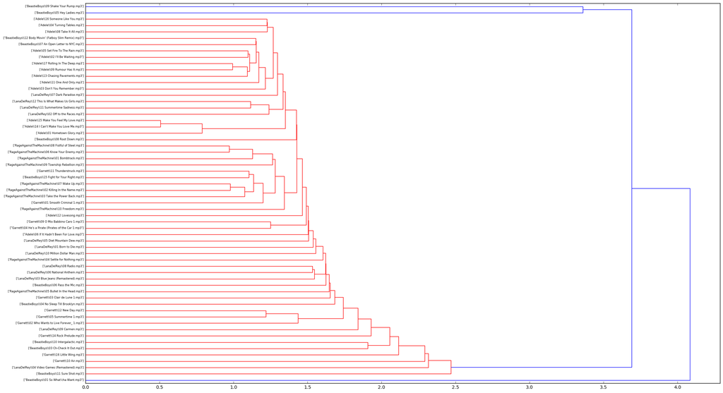

```python
#method : single
#metric: chebychev

link = linkage(subFeaturesTrain1.values[:,1:], metric='chebychev', method = 'single')

hierarchy.set_link_color_palette(['r', 'g', 'b'])
fig, axes = plt.subplots(figsize=(25, 15))

dendro = dendrogram(link, orientation='right', labels=subFeaturesTrain1.values[:,:1])
```

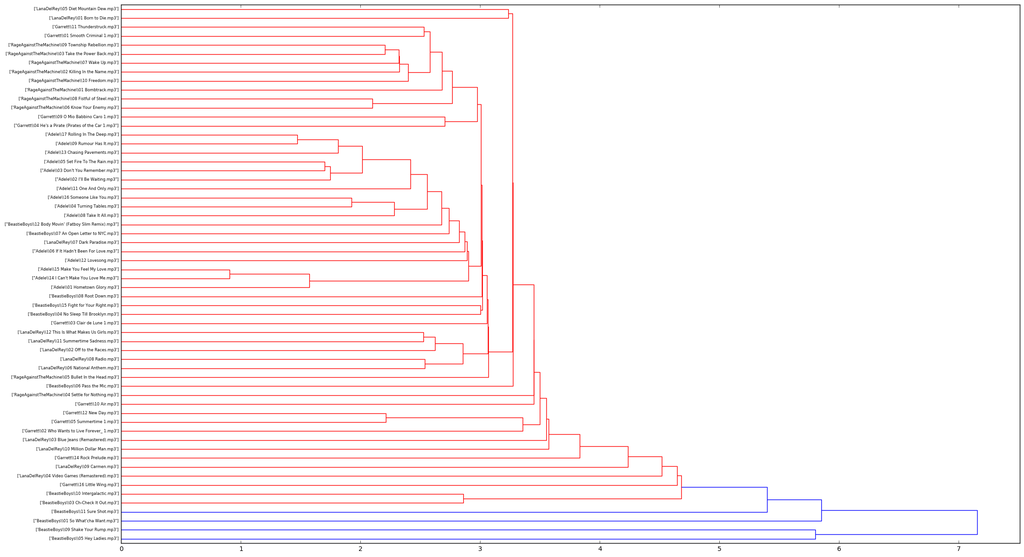

```python
from scipy.cluster import hierarchy
from scipy.cluster.hierarchy import linkage
from scipy.cluster.hierarchy import dendrogram
from scipy.cluster.hierarchy import fcluster

#method : single
#metric: euclidean

link = linkage(subFeaturesTrain1.values[:,1:], metric='euclidean', method = 'single')

hierarchy.set_link_color_palette(['r', 'g', 'b'])
fig, axes = plt.subplots(figsize=(25, 15))

dendro = dendrogram(link, orientation='right', labels=subFeaturesTrain1.values[:,:1])
```

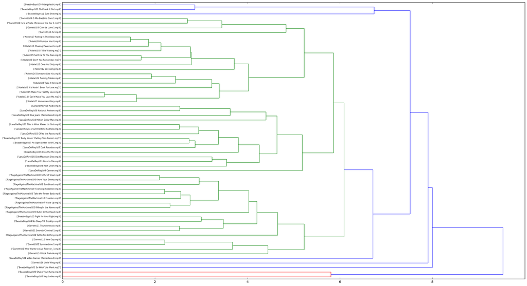

```python
#method : average
#metric: euclidean

link = linkage(subFeaturesTrain1.values[:,1:], metric='euclidean', method = 'average')

hierarchy.set_link_color_palette(['r', 'g', 'b'])
fig, axes = plt.subplots(figsize=(25, 15))

dendro = dendrogram(link, orientation='right', labels=subFeaturesTrain1.values[:,:1])
```

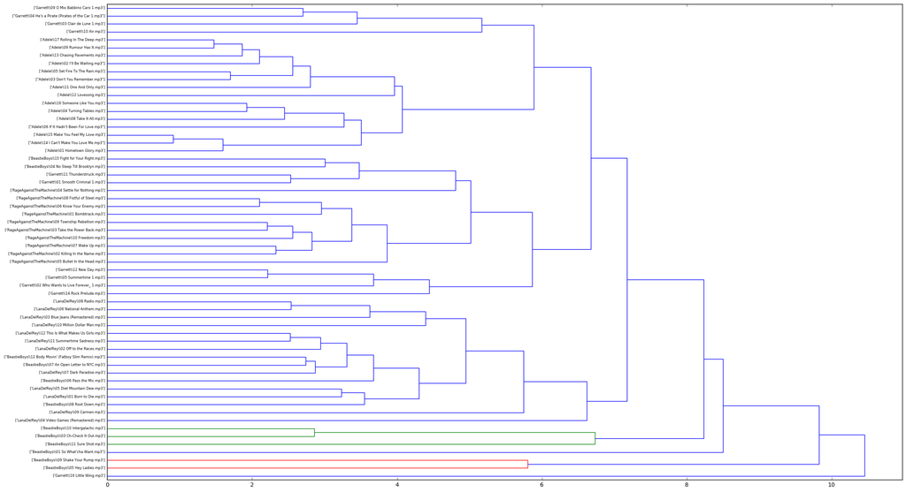

```python
#method : weighted
#metric: euclidean

link = linkage(subFeaturesTrain1.values[:,1:], metric='euclidean', method = 'weighted')

hierarchy.set_link_color_palette(['r', 'g', 'b'])
fig, axes = plt.subplots(figsize=(25, 15))

dendro = dendrogram(link, orientation='right', labels=subFeaturesTrain1.values[:,:1])
```

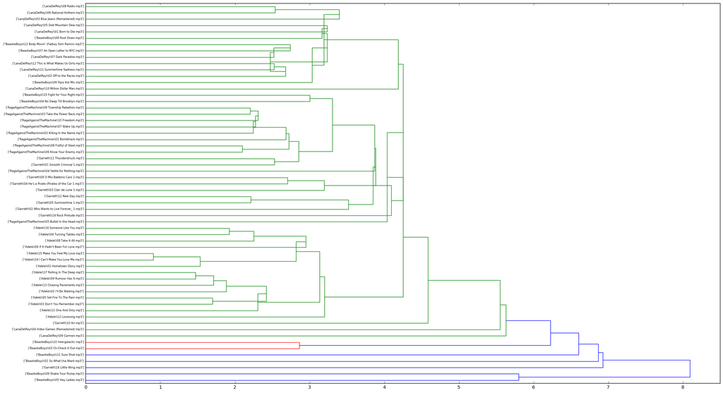

```python
#method : centroid
#metric: euclidean

link = linkage(subFeaturesTrain1.values[:,1:], metric='euclidean', method = 'centroid')

hierarchy.set_link_color_palette(['r', 'g', 'b'])
fig, axes = plt.subplots(figsize=(25, 15))

dendro = dendrogram(link, orientation='right', labels=subFeaturesTrain1.values[:,:1])
```

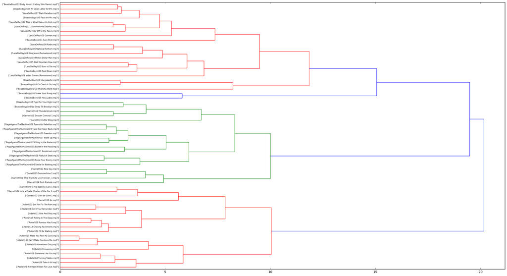

```python
#method : ward
#metric: euclidean
#distance_sorted {default}

link = linkage(subFeaturesTrain1.values[:,1:], metric='euclidean', method = 'ward')

hierarchy.set_link_color_palette(['r', 'g', 'b'])
fig, axes = plt.subplots(figsize=(25, 15))

dendro = dendrogram(link, orientation='right', labels=subFeaturesTrain1.values[:,:1], distance_sort=True)
```

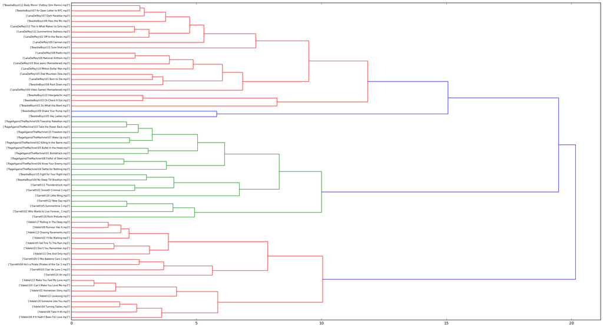

```python
#method : ward
#metric: euclidean
#count_sorted

link = linkage(subFeaturesTrain1.values[:,1:], metric='euclidean', method = 'ward')

hierarchy.set_link_color_palette(['r', 'g', 'b'])
fig, axes = plt.subplots(figsize=(25, 15))

dendro = dendrogram(link, orientation='right', labels=subFeaturesTrain1.values[:,:1], count_sort=True)
```

2.Für welche Parameterkonstellation erlangen Sie das für Sie subjektiv betrachtet günstigste Ergebnis?

### Auswertung:

Für die Parameter:

- Metric: Euclid
- Method: Ward
- Sort: Count

Erhalten wir die subjektiv günstigsten Ergebnisse. Beim vergleichen des Dendrograms kommen wir von einer fehlerhaften Anzeige (Dendrogram1) nach und nach zu einer geordneteren Ansicht, welche deutlich leserlicher ist.

Wenn man das Dendrogram genauer betrachtet, sieht man, dass beim Clustern die einzelnen Interpreten gut voneinander getrennt wurden. Man kann erkennen, dass die Interpreten ihren eigenen Stil haben, welcher sich durch die meisten Titel zieht. Zum Beispiel sieht man bei Adele, dass sich die Lieder "Make You Feel My Love" und "Can't Make You Love Me" extrem ähnlich sind.

Allgemein gibt es nur einige kleinere Außreiser z.B. von Garrett im großen Cluster von Adele. Der Interpret "BeastieBoys" vermischt sich dagegen stärker mit den Titeln von "LanaDelRey".

Interessant ist der "Ausreißer" der Titel "Shake Your Rump" und "Hey Ladies" der Band "BeastieBoys". Diese weißen eine relativ große Distanz zu anderen Titeln der selben Band auf.

3.Überlegen Sie sich Ansätze um diese Art der Musikgruppierung zu verbessern?

Im oben angewandten Verfahren werden alle Songs in 2 Teile aufgesplittet. Der 1. Teil wird dann mit allen 2. Teilen auf Ähnlichkeit verglichen. Dies funktioniert mit den meisten Songs relativ gut, dass der 2. Teil eines Songs dem 1. Teil am ähnlichsten ist. Es gibt allerdings Ausnahmen, bei denen die 2 Teile sich stark unterscheiden da z.B. die erste Hälfte hauptsächlich aus einem leisen Intro besteht und erst im 2. Teil der Rythmus sich verändert. Diese Ausreißer verschlechtern die allgemeine Genauigkeit der Groupierung.

Eine Möglichkeit dies zu verbessern wäre es Songs die aus zwei sehr unterschiedlichen Hälften bestehen als 2 separate Songs zu betrachten die immer direkt nacheinander abgespielt werden. Der Song der in der Playlist zuvor gespielt wird, muss mit der 1. Hälfte zusammenpassen, die 2. Hälfte muss mit dem Song zusammenpassen, der danach gespielt wird.

Bsp.: Songs A, B, C, D und E wobei B in B1 und B2 gesplittet wird

```
                +---+ A
          +-----+
          |     +---+ C
   +------+
      |   |     +---+ B1
      |   +-----+
      |         +---+ D
      |
      +-------------+ E
             |
             +------+ B2
```

Beim Iterieren über das Cluster um die Playliste zu generieren muss bei B1 nach B2 gesprungen werden. Bei dieser Implementierung kann es jedoch passieren, dass nicht alle Songs in einer Playliste landen.